# Risk Factor Analysis

## Outcome Variable

**Outcome Variable:** ever_wasted

## Predictor Variables

**Intervention Variable:** meducyrs

**Adjustment Set:**

unadjusted

## Stratifying Variables

The analysis was stratified on these variable(s):

- agecat
- studyid
- country

## Data Summary

| agecat | studyid | country | meducyrs | ever_wasted | n_cell | n |
| --- | --- | --- | --- | --- | --- | --- |
| 0-24 months | CMC-V-BCS-2002 | INDIA | High | 0 | 69 | 373 |
| 0-24 months | CMC-V-BCS-2002 | INDIA | High | 1 | 89 | 373 |
| 0-24 months | CMC-V-BCS-2002 | INDIA | Low | 0 | 38 | 373 |
| 0-24 months | CMC-V-BCS-2002 | INDIA | Low | 1 | 68 | 373 |
| 0-24 months | CMC-V-BCS-2002 | INDIA | Medium | 0 | 38 | 373 |
| 0-24 months | CMC-V-BCS-2002 | INDIA | Medium | 1 | 71 | 373 |
| 0-24 months | COHORTS | GUATEMALA | High | 0 | 218 | 1322 |
| 0-24 months | COHORTS | GUATEMALA | High | 1 | 62 | 1322 |
| 0-24 months | COHORTS | GUATEMALA | Low | 0 | 465 | 1322 |
| 0-24 months | COHORTS | GUATEMALA | Low | 1 | 162 | 1322 |
| 0-24 months | COHORTS | GUATEMALA | Medium | 0 | 300 | 1322 |
| 0-24 months | COHORTS | GUATEMALA | Medium | 1 | 115 | 1322 |
| 0-24 months | COHORTS | INDIA | High | 0 | 596 | 5844 |
| 0-24 months | COHORTS | INDIA | High | 1 | 197 | 5844 |
| 0-24 months | COHORTS | INDIA | Low | 0 | 1175 | 5844 |
| 0-24 months | COHORTS | INDIA | Low | 1 | 776 | 5844 |
| 0-24 months | COHORTS | INDIA | Medium | 0 | 2127 | 5844 |
| 0-24 months | COHORTS | INDIA | Medium | 1 | 973 | 5844 |
| 0-24 months | COHORTS | PHILIPPINES | High | 0 | 727 | 3045 |
| 0-24 months | COHORTS | PHILIPPINES | High | 1 | 441 | 3045 |
| 0-24 months | COHORTS | PHILIPPINES | Low | 0 | 496 | 3045 |
| 0-24 months | COHORTS | PHILIPPINES | Low | 1 | 405 | 3045 |
| 0-24 months | COHORTS | PHILIPPINES | Medium | 0 | 593 | 3045 |
| 0-24 months | COHORTS | PHILIPPINES | Medium | 1 | 383 | 3045 |
| 0-24 months | EE | PAKISTAN | High | 0 | 7 | 377 |
| 0-24 months | EE | PAKISTAN | High | 1 | 8 | 377 |
| 0-24 months | EE | PAKISTAN | Low | 0 | 129 | 377 |
| 0-24 months | EE | PAKISTAN | Low | 1 | 200 | 377 |
| 0-24 months | EE | PAKISTAN | Medium | 0 | 18 | 377 |
| 0-24 months | EE | PAKISTAN | Medium | 1 | 15 | 377 |

[output cut: 402 more lines]

The following strata were considered:

- agecat: 0-24 months, studyid: CMC-V-BCS-2002, country: INDIA
- agecat: 0-24 months, studyid: COHORTS, country: GUATEMALA
- agecat: 0-24 months, studyid: COHORTS, country: INDIA
- agecat: 0-24 months, studyid: COHORTS, country: PHILIPPINES
- agecat: 0-24 months, studyid: EE, country: PAKISTAN
- agecat: 0-24 months, studyid: GMS-Nepal, country: NEPAL
- agecat: 0-24 months, studyid: Guatemala BSC, country: GUATEMALA
- agecat: 0-24 months, studyid: IRC, country: INDIA
- agecat: 0-24 months, studyid: LCNI-5, country: MALAWI
- agecat: 0-24 months, studyid: MAL-ED, country: BANGLADESH
- agecat: 0-24 months, studyid: MAL-ED, country: BRAZIL
- agecat: 0-24 months, studyid: MAL-ED, country: INDIA
- agecat: 0-24 months, studyid: MAL-ED, country: NEPAL
- agecat: 0-24 months, studyid: MAL-ED, country: PERU
- agecat: 0-24 months, studyid: MAL-ED, country: SOUTH AFRICA
- agecat: 0-24 months, studyid: MAL-ED, country: TANZANIA, UNITED REPUBLIC OF
- agecat: 0-24 months, studyid: NIH-Birth, country: BANGLADESH
- agecat: 0-24 months, studyid: NIH-Crypto, country: BANGLADESH
- agecat: 0-24 months, studyid: PROBIT, country: BELARUS
- agecat: 0-24 months, studyid: PROVIDE, country: BANGLADESH
- agecat: 0-24 months, studyid: SAS-CompFeed, country: INDIA
- agecat: 0-24 months, studyid: SAS-FoodSuppl, country: INDIA
- agecat: 0-24 months, studyid: TanzaniaChild2, country: TANZANIA, UNITED REPUBLIC OF
- agecat: 0-24 months, studyid: ZVITAMBO, country: ZIMBABWE
- agecat: 0-6 months, studyid: CMC-V-BCS-2002, country: INDIA
- agecat: 0-6 months, studyid: COHORTS, country: GUATEMALA
- agecat: 0-6 months, studyid: COHORTS, country: INDIA
- agecat: 0-6 months, studyid: COHORTS, country: PHILIPPINES
- agecat: 0-6 months, studyid: EE, country: PAKISTAN
- agecat: 0-6 months, studyid: GMS-Nepal, country: NEPAL
- agecat: 0-6 months, studyid: Guatemala BSC, country: GUATEMALA
- agecat: 0-6 months, studyid: IRC, country: INDIA
- agecat: 0-6 months, studyid: LCNI-5, country: MALAWI
- agecat: 0-6 months, studyid: MAL-ED, country: BANGLADESH
- agecat: 0-6 months, studyid: MAL-ED, country: BRAZIL
- agecat: 0-6 months, studyid: MAL-ED, country: INDIA
- agecat: 0-6 months, studyid: MAL-ED, country: NEPAL
- agecat: 0-6 months, studyid: MAL-ED, country: PERU
- agecat: 0-6 months, studyid: MAL-ED, country: SOUTH AFRICA
- agecat: 0-6 months, studyid: MAL-ED, country: TANZANIA, UNITED REPUBLIC OF
- agecat: 0-6 months, studyid: NIH-Birth, country: BANGLADESH
- agecat: 0-6 months, studyid: NIH-Crypto, country: BANGLADESH
- agecat: 0-6 months, studyid: PROBIT, country: BELARUS
- agecat: 0-6 months, studyid: PROVIDE, country: BANGLADESH
- agecat: 0-6 months, studyid: SAS-CompFeed, country: INDIA
- agecat: 0-6 months, studyid: SAS-FoodSuppl, country: INDIA
- agecat: 0-6 months, studyid: TanzaniaChild2, country: TANZANIA, UNITED REPUBLIC OF
- agecat: 0-6 months, studyid: ZVITAMBO, country: ZIMBABWE
- agecat: 6-24 months, studyid: CMC-V-BCS-2002, country: INDIA
- agecat: 6-24 months, studyid: COHORTS, country: GUATEMALA
- agecat: 6-24 months, studyid: COHORTS, country: INDIA
- agecat: 6-24 months, studyid: COHORTS, country: PHILIPPINES
- agecat: 6-24 months, studyid: EE, country: PAKISTAN
- agecat: 6-24 months, studyid: GMS-Nepal, country: NEPAL
- agecat: 6-24 months, studyid: Guatemala BSC, country: GUATEMALA
- agecat: 6-24 months, studyid: IRC, country: INDIA
- agecat: 6-24 months, studyid: LCNI-5, country: MALAWI
- agecat: 6-24 months, studyid: MAL-ED, country: BANGLADESH
- agecat: 6-24 months, studyid: MAL-ED, country: BRAZIL
- agecat: 6-24 months, studyid: MAL-ED, country: INDIA
- agecat: 6-24 months, studyid: MAL-ED, country: NEPAL
- agecat: 6-24 months, studyid: MAL-ED, country: PERU
- agecat: 6-24 months, studyid: MAL-ED, country: SOUTH AFRICA
- agecat: 6-24 months, studyid: MAL-ED, country: TANZANIA, UNITED REPUBLIC OF
- agecat: 6-24 months, studyid: NIH-Birth, country: BANGLADESH
- agecat: 6-24 months, studyid: NIH-Crypto, country: BANGLADESH
- agecat: 6-24 months, studyid: PROBIT, country: BELARUS
- agecat: 6-24 months, studyid: PROVIDE, country: BANGLADESH
- agecat: 6-24 months, studyid: SAS-CompFeed, country: INDIA
- agecat: 6-24 months, studyid: SAS-FoodSuppl, country: INDIA
- agecat: 6-24 months, studyid: TanzaniaChild2, country: TANZANIA, UNITED REPUBLIC OF
- agecat: 6-24 months, studyid: ZVITAMBO, country: ZIMBABWE

### Dropped Strata

Some strata were dropped due to rare outcomes:

- agecat: 0-24 months, studyid: MAL-ED, country: BRAZIL
- agecat: 0-24 months, studyid: MAL-ED, country: PERU
- agecat: 0-24 months, studyid: MAL-ED, country: TANZANIA, UNITED REPUBLIC OF
- agecat: 0-6 months, studyid: EE, country: PAKISTAN
- agecat: 0-6 months, studyid: Guatemala BSC, country: GUATEMALA
- agecat: 0-6 months, studyid: LCNI-5, country: MALAWI
- agecat: 0-6 months, studyid: MAL-ED, country: BRAZIL
- agecat: 0-6 months, studyid: MAL-ED, country: PERU
- agecat: 0-6 months, studyid: MAL-ED, country: TANZANIA, UNITED REPUBLIC OF
- agecat: 0-6 months, studyid: SAS-FoodSuppl, country: INDIA
- agecat: 6-24 months, studyid: Guatemala BSC, country: GUATEMALA
- agecat: 6-24 months, studyid: MAL-ED, country: BRAZIL
- agecat: 6-24 months, studyid: MAL-ED, country: PERU
- agecat: 6-24 months, studyid: MAL-ED, country: TANZANIA, UNITED REPUBLIC OF

## Methods Detail

We’re interested in the causal parameters $E[Y_a]$ for all values of $a \in \mathcal{A}$. These parameters represent the mean outcome if, possibly contrary to fact, we intervened to set all units to have $A=a$. Under the randomization and positivity assumptions, these are identified by the statistical parameters $\psi_a=E_W[E_{Y|A,W}(Y|A=a,W)]$. In addition, we’re interested in the mean of $Y$, $E[Y]$ under no intervention (the observed mean). We will estimate these parameters by using SuperLearner to fit the relevant likelihood factors – $E_{Y|A,W}(Y|A=a,W)$ and $p(A=a|W)$, and then updating our likelihood fit using a joint TMLE.

For unadjusted analyses ($W=\{\}$), initial likelihoods were estimated using Lrnr_glm to estimate the simple $E(Y|A)$ and Lrnr_mean to estimate $p(A)$. For adjusted analyses, a small library containing Lrnr_glmnet, Lrnr_xgboost, and Lrnr_mean was used.

Having estimated these parameters, we will then use the delta method to estimate relative risks and attributable risks relative to a prespecified baseline level of $A$.

# Results Detail

## Results Plots

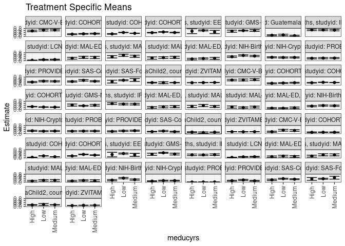

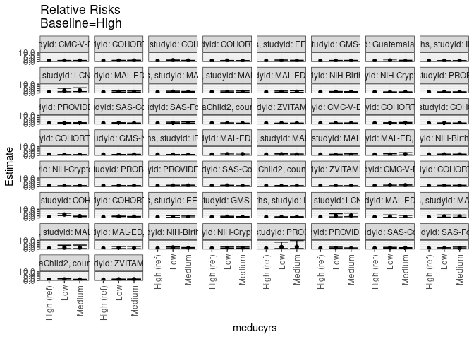

[figure not shown]

[figure not shown]

## Results Table

### Parameter: TSM

| agecat | studyid | country | intervention_level | baseline_level | estimate | ci_lower | ci_upper |
| --- | --- | --- | --- | --- | --- | --- | --- |
| 0-24 months | CMC-V-BCS-2002 | INDIA | High | NA | 0.5632911 | 0.4858512 | 0.6407311 |
| 0-24 months | CMC-V-BCS-2002 | INDIA | Low | NA | 0.6415094 | 0.5500942 | 0.7329247 |
| 0-24 months | CMC-V-BCS-2002 | INDIA | Medium | NA | 0.6513761 | 0.5617959 | 0.7409564 |
| 0-24 months | COHORTS | GUATEMALA | High | NA | 0.2214286 | 0.1727767 | 0.2700804 |
| 0-24 months | COHORTS | GUATEMALA | Low | NA | 0.2583732 | 0.2240968 | 0.2926496 |
| 0-24 months | COHORTS | GUATEMALA | Medium | NA | 0.2771084 | 0.2340310 | 0.3201859 |
| 0-24 months | COHORTS | INDIA | High | NA | 0.2484237 | 0.2183469 | 0.2785005 |
| 0-24 months | COHORTS | INDIA | Low | NA | 0.3977447 | 0.3760253 | 0.4194642 |
| 0-24 months | COHORTS | INDIA | Medium | NA | 0.3138710 | 0.2975336 | 0.3302084 |
| 0-24 months | COHORTS | PHILIPPINES | High | NA | 0.3775685 | 0.3497623 | 0.4053747 |
| 0-24 months | COHORTS | PHILIPPINES | Low | NA | 0.4495006 | 0.4170142 | 0.4819869 |
| 0-24 months | COHORTS | PHILIPPINES | Medium | NA | 0.3924180 | 0.3617793 | 0.4230568 |
| 0-24 months | EE | PAKISTAN | High | NA | 0.5333333 | 0.2805305 | 0.7861362 |
| 0-24 months | EE | PAKISTAN | Low | NA | 0.6079027 | 0.5550776 | 0.6607279 |
| 0-24 months | EE | PAKISTAN | Medium | NA | 0.4545455 | 0.2844331 | 0.6246578 |
| 0-24 months | GMS-Nepal | NEPAL | High | NA | 0.5357143 | 0.4289844 | 0.6424441 |
| 0-24 months | GMS-Nepal | NEPAL | Low | NA | 0.5958333 | 0.5519006 | 0.6397661 |
| 0-24 months | GMS-Nepal | NEPAL | Medium | NA | 0.6050420 | 0.5171477 | 0.6929364 |
| 0-24 months | Guatemala BSC | GUATEMALA | High | NA | 0.1101695 | 0.0535765 | 0.1667625 |
| 0-24 months | Guatemala BSC | GUATEMALA | Low | NA | 0.1447368 | 0.0654954 | 0.2239782 |
| 0-24 months | Guatemala BSC | GUATEMALA | Medium | NA | 0.0681818 | 0.0154251 | 0.1209386 |
| 0-24 months | IRC | INDIA | High | NA | 0.6693548 | 0.5864506 | 0.7522591 |
| 0-24 months | IRC | INDIA | Low | NA | 0.6598639 | 0.5831855 | 0.7365424 |
| 0-24 months | IRC | INDIA | Medium | NA | 0.6402878 | 0.5604081 | 0.7201674 |
| 0-24 months | LCNI-5 | MALAWI | High | NA | 0.0369128 | 0.0154923 | 0.0583332 |
| 0-24 months | LCNI-5 | MALAWI | Low | NA | 0.0996169 | 0.0632610 | 0.1359728 |
| 0-24 months | LCNI-5 | MALAWI | Medium | NA | 0.1098039 | 0.0714070 | 0.1482009 |
| 0-24 months | MAL-ED | BANGLADESH | High | NA | 0.2435897 | 0.1481057 | 0.3390738 |
| 0-24 months | MAL-ED | BANGLADESH | Low | NA | 0.3428571 | 0.2314001 | 0.4543142 |
| 0-24 months | MAL-ED | BANGLADESH | Medium | NA | 0.3230769 | 0.2091213 | 0.4370326 |

[output cut: 144 more lines]

### Parameter: E(Y)

| agecat | studyid | country | intervention_level | baseline_level | estimate | ci_lower | ci_upper |
| --- | --- | --- | --- | --- | --- | --- | --- |
| 0-24 months | CMC-V-BCS-2002 | INDIA | NA | NA | 0.6112601 | 0.5617242 | 0.6607959 |
| 0-24 months | COHORTS | GUATEMALA | NA | NA | 0.2564297 | 0.2328823 | 0.2799770 |
| 0-24 months | COHORTS | INDIA | NA | NA | 0.3329911 | 0.3209071 | 0.3450751 |
| 0-24 months | COHORTS | PHILIPPINES | NA | NA | 0.4036125 | 0.3861835 | 0.4210415 |
| 0-24 months | EE | PAKISTAN | NA | NA | 0.5915119 | 0.5418269 | 0.6411970 |
| 0-24 months | GMS-Nepal | NEPAL | NA | NA | 0.5900439 | 0.5531320 | 0.6269559 |
| 0-24 months | Guatemala BSC | GUATEMALA | NA | NA | 0.1063830 | 0.0703329 | 0.1424331 |
| 0-24 months | IRC | INDIA | NA | NA | 0.6560976 | 0.6100625 | 0.7021326 |
| 0-24 months | LCNI-5 | MALAWI | NA | NA | 0.0798526 | 0.0612199 | 0.0984853 |
| 0-24 months | MAL-ED | BANGLADESH | NA | NA | 0.3004695 | 0.2387555 | 0.3621835 |
| 0-24 months | MAL-ED | INDIA | NA | NA | 0.4727273 | 0.4066048 | 0.5388497 |
| 0-24 months | MAL-ED | NEPAL | NA | NA | 0.3111111 | 0.2504855 | 0.3717368 |
| 0-24 months | MAL-ED | SOUTH AFRICA | NA | NA | 0.2051282 | 0.1602507 | 0.2500058 |
| 0-24 months | NIH-Birth | BANGLADESH | NA | NA | 0.4775641 | 0.4383415 | 0.5167867 |
| 0-24 months | NIH-Crypto | BANGLADESH | NA | NA | 0.3298153 | 0.2963239 | 0.3633067 |
| 0-24 months | PROBIT | BELARUS | NA | NA | 0.2554148 | 0.1971257 | 0.3137039 |
| 0-24 months | PROVIDE | BANGLADESH | NA | NA | 0.3514286 | 0.3160364 | 0.3868207 |
| 0-24 months | SAS-CompFeed | INDIA | NA | NA | 0.4150694 | 0.3581204 | 0.4720184 |
| 0-24 months | SAS-FoodSuppl | INDIA | NA | NA | 0.4712919 | 0.4233811 | 0.5192026 |
| 0-24 months | TanzaniaChild2 | TANZANIA, UNITED REPUBLIC OF | NA | NA | 0.2367980 | 0.2197367 | 0.2538593 |
| 0-24 months | ZVITAMBO | ZIMBABWE | NA | NA | 0.2366078 | 0.2295489 | 0.2436667 |
| 0-6 months | CMC-V-BCS-2002 | INDIA | NA | NA | 0.5163043 | 0.4651769 | 0.5674318 |
| 0-6 months | COHORTS | GUATEMALA | NA | NA | 0.2007612 | 0.1765324 | 0.2249900 |
| 0-6 months | COHORTS | INDIA | NA | NA | 0.2511554 | 0.2398221 | 0.2624886 |
| 0-6 months | COHORTS | PHILIPPINES | NA | NA | 0.2355453 | 0.2204685 | 0.2506222 |
| 0-6 months | GMS-Nepal | NEPAL | NA | NA | 0.3762811 | 0.3399226 | 0.4126397 |
| 0-6 months | IRC | INDIA | NA | NA | 0.5439024 | 0.4956326 | 0.5921723 |
| 0-6 months | MAL-ED | BANGLADESH | NA | NA | 0.2253521 | 0.1691098 | 0.2815944 |
| 0-6 months | MAL-ED | INDIA | NA | NA | 0.3181818 | 0.2564942 | 0.3798694 |
| 0-6 months | MAL-ED | NEPAL | NA | NA | 0.2000000 | 0.1476178 | 0.2523822 |
| 0-6 months | MAL-ED | SOUTH AFRICA | NA | NA | 0.1121795 | 0.0771053 | 0.1472536 |
| 0-6 months | NIH-Birth | BANGLADESH | NA | NA | 0.3569132 | 0.3192325 | 0.3945938 |
| 0-6 months | NIH-Crypto | BANGLADESH | NA | NA | 0.2572559 | 0.2261171 | 0.2883948 |
| 0-6 months | PROBIT | BELARUS | NA | NA | 0.2500148 | 0.1915461 | 0.3084835 |
| 0-6 months | PROVIDE | BANGLADESH | NA | NA | 0.2585714 | 0.2261125 | 0.2910304 |
| 0-6 months | SAS-CompFeed | INDIA | NA | NA | 0.2199336 | 0.1753445 | 0.2645227 |
| 0-6 months | TanzaniaChild2 | TANZANIA, UNITED REPUBLIC OF | NA | NA | 0.1395641 | 0.1256566 | 0.1534717 |
| 0-6 months | ZVITAMBO | ZIMBABWE | NA | NA | 0.1810164 | 0.1745999 | 0.1874330 |
| 6-24 months | CMC-V-BCS-2002 | INDIA | NA | NA | 0.2654155 | 0.2205451 | 0.3102860 |
| 6-24 months | COHORTS | GUATEMALA | NA | NA | 0.1277129 | 0.1088047 | 0.1466210 |
| 6-24 months | COHORTS | INDIA | NA | NA | 0.1266654 | 0.1178579 | 0.1354730 |
| 6-24 months | COHORTS | PHILIPPINES | NA | NA | 0.2666429 | 0.2502871 | 0.2829988 |
| 6-24 months | EE | PAKISTAN | NA | NA | 0.4258760 | 0.3754921 | 0.4762599 |
| 6-24 months | GMS-Nepal | NEPAL | NA | NA | 0.4735945 | 0.4331684 | 0.5140207 |
| 6-24 months | IRC | INDIA | NA | NA | 0.3097561 | 0.2649438 | 0.3545684 |
| 6-24 months | LCNI-5 | MALAWI | NA | NA | 0.0772105 | 0.0587369 | 0.0956840 |
| 6-24 months | MAL-ED | BANGLADESH | NA | NA | 0.1384615 | 0.0898601 | 0.1870630 |
| 6-24 months | MAL-ED | INDIA | NA | NA | 0.2657005 | 0.2053824 | 0.3260185 |
| 6-24 months | MAL-ED | NEPAL | NA | NA | 0.1545455 | 0.1066715 | 0.2024194 |
| 6-24 months | MAL-ED | SOUTH AFRICA | NA | NA | 0.1428571 | 0.1001583 | 0.1855560 |
| 6-24 months | NIH-Birth | BANGLADESH | NA | NA | 0.2933579 | 0.2549918 | 0.3317241 |
| 6-24 months | NIH-Crypto | BANGLADESH | NA | NA | 0.1315068 | 0.1069744 | 0.1560393 |
| 6-24 months | PROBIT | BELARUS | NA | NA | 0.0083745 | 0.0044130 | 0.0123360 |
| 6-24 months | PROVIDE | BANGLADESH | NA | NA | 0.1609756 | 0.1319065 | 0.1900447 |
| 6-24 months | SAS-CompFeed | INDIA | NA | NA | 0.3059755 | 0.2638053 | 0.3481458 |
| 6-24 months | SAS-FoodSuppl | INDIA | NA | NA | 0.3557214 | 0.3088651 | 0.4025777 |
| 6-24 months | TanzaniaChild2 | TANZANIA, UNITED REPUBLIC OF | NA | NA | 0.1606166 | 0.1445647 | 0.1766685 |
| 6-24 months | ZVITAMBO | ZIMBABWE | NA | NA | 0.0959259 | 0.0903717 | 0.1014802 |

### Parameter: RR

| agecat | studyid | country | intervention_level | baseline_level | estimate | ci_lower | ci_upper |
| --- | --- | --- | --- | --- | --- | --- | --- |
| 0-24 months | CMC-V-BCS-2002 | INDIA | High | High | 1.0000000 | 1.0000000 | 1.0000000 |
| 0-24 months | CMC-V-BCS-2002 | INDIA | Low | High | 1.1388594 | 0.9342803 | 1.3882353 |
| 0-24 months | CMC-V-BCS-2002 | INDIA | Medium | High | 1.1563756 | 0.9520238 | 1.4045916 |
| 0-24 months | COHORTS | GUATEMALA | High | High | 1.0000000 | 1.0000000 | 1.0000000 |
| 0-24 months | COHORTS | GUATEMALA | Low | High | 1.1668467 | 0.9027073 | 1.5082754 |
| 0-24 months | COHORTS | GUATEMALA | Medium | High | 1.2514574 | 0.9561492 | 1.6379721 |
| 0-24 months | COHORTS | INDIA | High | High | 1.0000000 | 1.0000000 | 1.0000000 |
| 0-24 months | COHORTS | INDIA | Low | High | 1.6010740 | 1.4019430 | 1.8284895 |
| 0-24 months | COHORTS | INDIA | Medium | High | 1.2634501 | 1.1074506 | 1.4414243 |
| 0-24 months | COHORTS | PHILIPPINES | High | High | 1.0000000 | 1.0000000 | 1.0000000 |
| 0-24 months | COHORTS | PHILIPPINES | Low | High | 1.1905139 | 1.0737973 | 1.3199171 |
| 0-24 months | COHORTS | PHILIPPINES | Medium | High | 1.0393294 | 0.9335564 | 1.1570866 |
| 0-24 months | EE | PAKISTAN | High | High | 1.0000000 | 1.0000000 | 1.0000000 |
| 0-24 months | EE | PAKISTAN | Low | High | 1.1398176 | 0.7039580 | 1.8455421 |
| 0-24 months | EE | PAKISTAN | Medium | High | 0.8522727 | 0.4658985 | 1.5590708 |
| 0-24 months | GMS-Nepal | NEPAL | High | High | 1.0000000 | 1.0000000 | 1.0000000 |
| 0-24 months | GMS-Nepal | NEPAL | Low | High | 1.1122222 | 0.8993568 | 1.3754699 |
| 0-24 months | GMS-Nepal | NEPAL | Medium | High | 1.1294118 | 0.8826111 | 1.4452242 |
| 0-24 months | Guatemala BSC | GUATEMALA | High | High | 1.0000000 | 1.0000000 | 1.0000000 |
| 0-24 months | Guatemala BSC | GUATEMALA | Low | High | 1.3137652 | 0.6201163 | 2.7833150 |
| 0-24 months | Guatemala BSC | GUATEMALA | Medium | High | 0.6188811 | 0.2444853 | 1.5666127 |
| 0-24 months | IRC | INDIA | High | High | 1.0000000 | 1.0000000 | 1.0000000 |
| 0-24 months | IRC | INDIA | Low | High | 0.9858208 | 0.8318400 | 1.1683049 |
| 0-24 months | IRC | INDIA | Medium | High | 0.9565745 | 0.8023635 | 1.1404243 |
| 0-24 months | LCNI-5 | MALAWI | High | High | 1.0000000 | 1.0000000 | 1.0000000 |
| 0-24 months | LCNI-5 | MALAWI | Low | High | 2.6987113 | 1.3596842 | 5.3564220 |
| 0-24 months | LCNI-5 | MALAWI | Medium | High | 2.9746881 | 1.5107766 | 5.8570996 |
| 0-24 months | MAL-ED | BANGLADESH | High | High | 1.0000000 | 1.0000000 | 1.0000000 |
| 0-24 months | MAL-ED | BANGLADESH | Low | High | 1.4075188 | 0.8458452 | 2.3421652 |
| 0-24 months | MAL-ED | BANGLADESH | Medium | High | 1.3263158 | 0.7827719 | 2.2472876 |

[output cut: 144 more lines]

### Parameter: PAR

| agecat | studyid | country | intervention_level | baseline_level | estimate | ci_lower | ci_upper |
| --- | --- | --- | --- | --- | --- | --- | --- |
| 0-24 months | CMC-V-BCS-2002 | INDIA | High | NA | 0.0479689 | -0.0100847 | 0.1060225 |
| 0-24 months | COHORTS | GUATEMALA | High | NA | 0.0350011 | -0.0088032 | 0.0788054 |
| 0-24 months | COHORTS | INDIA | High | NA | 0.0845674 | 0.0561925 | 0.1129423 |
| 0-24 months | COHORTS | PHILIPPINES | High | NA | 0.0260440 | 0.0040486 | 0.0480394 |
| 0-24 months | EE | PAKISTAN | High | NA | 0.0581786 | -0.1893941 | 0.3057514 |
| 0-24 months | GMS-Nepal | NEPAL | High | NA | 0.0543296 | -0.0454291 | 0.1540884 |
| 0-24 months | Guatemala BSC | GUATEMALA | High | NA | -0.0037865 | -0.0464720 | 0.0388989 |
| 0-24 months | IRC | INDIA | High | NA | -0.0132573 | -0.0827910 | 0.0562765 |
| 0-24 months | LCNI-5 | MALAWI | High | NA | 0.0429398 | 0.0212590 | 0.0646207 |
| 0-24 months | MAL-ED | BANGLADESH | High | NA | 0.0568797 | -0.0221673 | 0.1359268 |
| 0-24 months | MAL-ED | INDIA | High | NA | 0.0759019 | -0.0272321 | 0.1790358 |
| 0-24 months | MAL-ED | NEPAL | High | NA | 0.0469602 | -0.0586804 | 0.1526007 |
| 0-24 months | MAL-ED | SOUTH AFRICA | High | NA | 0.0367072 | -0.0283745 | 0.1017888 |
| 0-24 months | NIH-Birth | BANGLADESH | High | NA | 0.0730697 | 0.0116314 | 0.1345080 |
| 0-24 months | NIH-Crypto | BANGLADESH | High | NA | -0.0127044 | -0.0601013 | 0.0346926 |
| 0-24 months | PROBIT | BELARUS | High | NA | 0.0143026 | -0.0115476 | 0.0401527 |
| 0-24 months | PROVIDE | BANGLADESH | High | NA | 0.0578116 | 0.0091476 | 0.1064755 |
| 0-24 months | SAS-CompFeed | INDIA | High | NA | 0.0641377 | 0.0014335 | 0.1268420 |
| 0-24 months | SAS-FoodSuppl | INDIA | High | NA | 0.1298285 | -0.0089938 | 0.2686507 |
| 0-24 months | TanzaniaChild2 | TANZANIA, UNITED REPUBLIC OF | High | NA | 0.0000830 | -0.0286781 | 0.0288441 |
| 0-24 months | ZVITAMBO | ZIMBABWE | High | NA | 0.0080174 | 0.0015209 | 0.0145140 |
| 0-6 months | CMC-V-BCS-2002 | INDIA | High | NA | 0.0131196 | -0.0461596 | 0.0723988 |
| 0-6 months | COHORTS | GUATEMALA | High | NA | 0.0333193 | -0.0120696 | 0.0787083 |
| 0-6 months | COHORTS | INDIA | High | NA | 0.0271554 | -0.0008000 | 0.0551107 |
| 0-6 months | COHORTS | PHILIPPINES | High | NA | -0.0307218 | -0.0501334 | -0.0113102 |
| 0-6 months | GMS-Nepal | NEPAL | High | NA | -0.0522903 | -0.1511797 | 0.0465991 |
| 0-6 months | IRC | INDIA | High | NA | -0.0367427 | -0.1096661 | 0.0361807 |
| 0-6 months | MAL-ED | BANGLADESH | High | NA | 0.0458649 | -0.0256425 | 0.1173723 |
| 0-6 months | MAL-ED | INDIA | High | NA | 0.0324675 | -0.0631704 | 0.1281055 |
| 0-6 months | MAL-ED | NEPAL | High | NA | -0.0264151 | -0.1238221 | 0.0709920 |
| 0-6 months | MAL-ED | SOUTH AFRICA | High | NA | 0.0069163 | -0.0452773 | 0.0591099 |
| 0-6 months | NIH-Birth | BANGLADESH | High | NA | 0.0348793 | -0.0239828 | 0.0937414 |
| 0-6 months | NIH-Crypto | BANGLADESH | High | NA | -0.0183346 | -0.0626828 | 0.0260136 |
| 0-6 months | PROBIT | BELARUS | High | NA | 0.0117184 | -0.0141755 | 0.0376123 |
| 0-6 months | PROVIDE | BANGLADESH | High | NA | 0.0415502 | -0.0028069 | 0.0859072 |
| 0-6 months | SAS-CompFeed | INDIA | High | NA | 0.0273870 | -0.0081075 | 0.0628815 |
| 0-6 months | TanzaniaChild2 | TANZANIA, UNITED REPUBLIC OF | High | NA | -0.0069737 | -0.0307331 | 0.0167856 |
| 0-6 months | ZVITAMBO | ZIMBABWE | High | NA | -0.0021460 | -0.0080312 | 0.0037392 |
| 6-24 months | CMC-V-BCS-2002 | INDIA | High | NA | 0.0818712 | 0.0311600 | 0.1325825 |
| 6-24 months | COHORTS | GUATEMALA | High | NA | 0.0078781 | -0.0289486 | 0.0447049 |
| 6-24 months | COHORTS | INDIA | High | NA | 0.0773321 | 0.0614558 | 0.0932084 |
| 6-24 months | COHORTS | PHILIPPINES | High | NA | 0.0749921 | 0.0547814 | 0.0952027 |
| 6-24 months | EE | PAKISTAN | High | NA | 0.0925427 | -0.1419536 | 0.3270389 |
| 6-24 months | GMS-Nepal | NEPAL | High | NA | 0.1073974 | 0.0017075 | 0.2130872 |
| 6-24 months | IRC | INDIA | High | NA | 0.0033045 | -0.0646376 | 0.0712466 |
| 6-24 months | LCNI-5 | MALAWI | High | NA | 0.0396678 | 0.0180010 | 0.0613346 |
| 6-24 months | MAL-ED | BANGLADESH | High | NA | 0.0257855 | -0.0361817 | 0.0877527 |
| 6-24 months | MAL-ED | INDIA | High | NA | 0.0932867 | 0.0048956 | 0.1816778 |
| 6-24 months | MAL-ED | NEPAL | High | NA | 0.0583916 | -0.0170578 | 0.1338410 |
| 6-24 months | MAL-ED | SOUTH AFRICA | High | NA | 0.0347490 | -0.0283117 | 0.0978098 |
| 6-24 months | NIH-Birth | BANGLADESH | High | NA | 0.0959057 | 0.0401741 | 0.1516374 |
| 6-24 months | NIH-Crypto | BANGLADESH | High | NA | 0.0339459 | 0.0015314 | 0.0663603 |
| 6-24 months | PROBIT | BELARUS | High | NA | 0.0047709 | 0.0012075 | 0.0083343 |
| 6-24 months | PROVIDE | BANGLADESH | High | NA | 0.0187955 | -0.0204853 | 0.0580763 |
| 6-24 months | SAS-CompFeed | INDIA | High | NA | 0.0774987 | 0.0127837 | 0.1422137 |
| 6-24 months | SAS-FoodSuppl | INDIA | High | NA | 0.0307214 | -0.1075282 | 0.1689710 |
| 6-24 months | TanzaniaChild2 | TANZANIA, UNITED REPUBLIC OF | High | NA | 0.0127567 | -0.0140423 | 0.0395557 |
| 6-24 months | ZVITAMBO | ZIMBABWE | High | NA | 0.0159259 | 0.0107269 | 0.0211249 |

### Parameter: PAF

| agecat | studyid | country | intervention_level | baseline_level | estimate | ci_lower | ci_upper |
| --- | --- | --- | --- | --- | --- | --- | --- |
| 0-24 months | CMC-V-BCS-2002 | INDIA | High | NA | 0.0784755 | -0.0220119 | 0.1690826 |
| 0-24 months | COHORTS | GUATEMALA | High | NA | 0.1364939 | -0.0521715 | 0.2913296 |
| 0-24 months | COHORTS | INDIA | High | NA | 0.2539629 | 0.1638362 | 0.3343753 |
| 0-24 months | COHORTS | PHILIPPINES | High | NA | 0.0645272 | 0.0083921 | 0.1174845 |
| 0-24 months | EE | PAKISTAN | High | NA | 0.0983558 | -0.4344899 | 0.4332743 |
| 0-24 months | GMS-Nepal | NEPAL | High | NA | 0.0920773 | -0.0939495 | 0.2464701 |
| 0-24 months | Guatemala BSC | GUATEMALA | High | NA | -0.0355932 | -0.5254587 | 0.2969634 |
| 0-24 months | IRC | INDIA | High | NA | -0.0202063 | -0.1319179 | 0.0804803 |
| 0-24 months | LCNI-5 | MALAWI | High | NA | 0.5377388 | 0.2173819 | 0.7269608 |
| 0-24 months | MAL-ED | BANGLADESH | High | NA | 0.1893029 | -0.1202708 | 0.4133295 |
| 0-24 months | MAL-ED | INDIA | High | NA | 0.1605617 | -0.0893379 | 0.3531330 |
| 0-24 months | MAL-ED | NEPAL | High | NA | 0.1509434 | -0.2661054 | 0.4306184 |
| 0-24 months | MAL-ED | SOUTH AFRICA | High | NA | 0.1789474 | -0.2062972 | 0.4411597 |
| 0-24 months | NIH-Birth | BANGLADESH | High | NA | 0.1530051 | 0.0136800 | 0.2726494 |
| 0-24 months | NIH-Crypto | BANGLADESH | High | NA | -0.0385197 | -0.1926464 | 0.0956891 |
| 0-24 months | PROBIT | BELARUS | High | NA | 0.0559974 | -0.0509143 | 0.1520327 |
| 0-24 months | PROVIDE | BANGLADESH | High | NA | 0.1645044 | 0.0140038 | 0.2920329 |
| 0-24 months | SAS-CompFeed | INDIA | High | NA | 0.1545229 | 0.0008746 | 0.2845427 |
| 0-24 months | SAS-FoodSuppl | INDIA | High | NA | 0.2754736 | -0.0885530 | 0.5177648 |
| 0-24 months | TanzaniaChild2 | TANZANIA, UNITED REPUBLIC OF | High | NA | 0.0003506 | -0.1287945 | 0.1147202 |
| 0-24 months | ZVITAMBO | ZIMBABWE | High | NA | 0.0338850 | 0.0060418 | 0.0609482 |
| 0-6 months | CMC-V-BCS-2002 | INDIA | High | NA | 0.0254107 | -0.0964739 | 0.1337465 |
| 0-6 months | COHORTS | GUATEMALA | High | NA | 0.1659650 | -0.0930525 | 0.3636038 |
| 0-6 months | COHORTS | INDIA | High | NA | 0.1081217 | -0.0103802 | 0.2127252 |
| 0-6 months | COHORTS | PHILIPPINES | High | NA | -0.1304283 | -0.2157800 | -0.0510687 |
| 0-6 months | GMS-Nepal | NEPAL | High | NA | -0.1389661 | -0.4347283 | 0.0958262 |
| 0-6 months | IRC | INDIA | High | NA | -0.0675539 | -0.2106462 | 0.0586256 |
| 0-6 months | MAL-ED | BANGLADESH | High | NA | 0.2035256 | -0.1830425 | 0.4637797 |
| 0-6 months | MAL-ED | INDIA | High | NA | 0.1020408 | -0.2548107 | 0.3574085 |
| 0-6 months | MAL-ED | NEPAL | High | NA | -0.1320755 | -0.7398448 | 0.2633855 |
| 0-6 months | MAL-ED | SOUTH AFRICA | High | NA | 0.0616541 | -0.5401470 | 0.4283059 |
| 0-6 months | NIH-Birth | BANGLADESH | High | NA | 0.0977248 | -0.0832298 | 0.2484508 |
| 0-6 months | NIH-Crypto | BANGLADESH | High | NA | -0.0712699 | -0.2582395 | 0.0879167 |
| 0-6 months | PROBIT | BELARUS | High | NA | 0.0468709 | -0.0623097 | 0.1448303 |
| 0-6 months | PROVIDE | BANGLADESH | High | NA | 0.1606912 | -0.0290410 | 0.3154410 |
| 0-6 months | SAS-CompFeed | INDIA | High | NA | 0.1245238 | -0.0323145 | 0.2575339 |
| 0-6 months | TanzaniaChild2 | TANZANIA, UNITED REPUBLIC OF | High | NA | -0.0499678 | -0.2347294 | 0.1071465 |
| 0-6 months | ZVITAMBO | ZIMBABWE | High | NA | -0.0118551 | -0.0448934 | 0.0201385 |
| 6-24 months | CMC-V-BCS-2002 | INDIA | High | NA | 0.3084644 | 0.0931235 | 0.4726718 |
| 6-24 months | COHORTS | GUATEMALA | High | NA | 0.0616864 | -0.2757446 | 0.3098678 |
| 6-24 months | COHORTS | INDIA | High | NA | 0.6105226 | 0.4716226 | 0.7129085 |
| 6-24 months | COHORTS | PHILIPPINES | High | NA | 0.2812453 | 0.2023550 | 0.3523331 |
| 6-24 months | EE | PAKISTAN | High | NA | 0.2172996 | -0.5818690 | 0.6127240 |
| 6-24 months | GMS-Nepal | NEPAL | High | NA | 0.2267707 | -0.0323725 | 0.4208645 |
| 6-24 months | IRC | INDIA | High | NA | 0.0106680 | -0.2348875 | 0.2073952 |
| 6-24 months | LCNI-5 | MALAWI | High | NA | 0.5137620 | 0.1790225 | 0.7120172 |
| 6-24 months | MAL-ED | BANGLADESH | High | NA | 0.1862285 | -0.4042934 | 0.5284290 |
| 6-24 months | MAL-ED | INDIA | High | NA | 0.3510972 | -0.0750115 | 0.6083067 |
| 6-24 months | MAL-ED | NEPAL | High | NA | 0.3778281 | -0.3397954 | 0.7110768 |
| 6-24 months | MAL-ED | SOUTH AFRICA | High | NA | 0.2432432 | -0.3480406 | 0.5751754 |
| 6-24 months | NIH-Birth | BANGLADESH | High | NA | 0.3269238 | 0.1102495 | 0.4908331 |
| 6-24 months | NIH-Crypto | BANGLADESH | High | NA | 0.2581301 | -0.0291302 | 0.4652076 |
| 6-24 months | PROBIT | BELARUS | High | NA | 0.5696932 | -0.3834582 | 0.8661586 |
| 6-24 months | PROVIDE | BANGLADESH | High | NA | 0.1167600 | -0.1635016 | 0.3295129 |
| 6-24 months | SAS-CompFeed | INDIA | High | NA | 0.2532840 | 0.0114829 | 0.4359381 |
| 6-24 months | SAS-FoodSuppl | INDIA | High | NA | 0.0863636 | -0.3980277 | 0.4029221 |
| 6-24 months | TanzaniaChild2 | TANZANIA, UNITED REPUBLIC OF | High | NA | 0.0794232 | -0.1033578 | 0.2319249 |
| 6-24 months | ZVITAMBO | ZIMBABWE | High | NA | 0.1660232 | 0.1107788 | 0.2178354 |